# Govindarajulu Distribution in Stan

Deemah

2/14/2021

# Introduction

Flexible quantile density function is
$$q_X(u)=Ku^\alpha(1-u)^\beta, \quad K>0; \; \alpha, \beta \; \text{real}$$
This distribution has various names depending on values of parameters. We will be looking at the distribution with $\alpha=\gamma>0, \; \beta=1, \; K=\sigma\alpha(\alpha+1)$

This is Govindarajalu ditribution with quantile function

$$Q_X(u)=\sigma((\alpha+1)u^\alpha-\alpha u^{\alpha+1})$$

and quantile density function

$$q_X(u)=Ku^\alpha(1-u)=\sigma\alpha(\alpha-1)u^\alpha(1-u)$$
We will keep the alpha-sigma parametrization, even though some literature uses alpha-K parametrization.

In order to keep our functions versatile, let’s make both vectorized and non-vectorized versions. We will differentiate them by the suffix `_s` and `_v` for scalar and vector, respectively.

Need to make:

- `_cdf` equivalent, quantile function, to be named `govindarajulu_qf_s_cdf()` and `govindarajulu_qf_v_cdf()`
- `_lcdf` equivalent, log quantile function, to be named `govindarajulu_qf_s_lcdf()` and `govindarajulu_qf_v_lcdf()`
- `_lpdf` equivalent, log quantile density function, to be named `govindarajulu_qdf_s_lpdf()` and `govindarajulu_qdf_s_lpdf()` There’s no equivalent to `_lccdf`?
- `_rng` function is always scalar, which we will call `govindarajulu_q_s_rng()`

# Govindarajulu distribution

```
## rstan (Version 2.21.2, GitRev: 2e1f913d3ca3)
```

```
## For execution on a local, multicore CPU with excess RAM we recommend calling
## options(mc.cores = parallel::detectCores()).
## To avoid recompilation of unchanged Stan programs, we recommend calling
## rstan_options(auto_write = TRUE)
```

## qf (cdf)

Govindarajulu quantile function from Nair, Sankaran, and Dileepkumar (2020)

$$Q_X(u)=\sigma((\alpha+1)u^\alpha-\alpha u^{\alpha+1})=\sigma a u^a(1+1/a-u)$$

```stan
  real govindarajulu_qf_s_cdf(real p, real alpha, real sigma) {
    real inv_alpha = inv(alpha);
    // govindarajulu quantile function
    if (alpha<0)
      reject("alpha<0; found alpha =", alpha);
    if (sigma<0)
      reject("sigma<0; found sigma =", sigma);
  return sigma*alpha*pow(p, alpha)*(1+inv_alpha-p);
  }

  real govindarajulu_qf_v_cdf(vector p, real alpha, real sigma) {
    int N = rows(p);
    real inv_alpha=inv(alpha);
    // govindarajulu quantile function
    if (alpha<0)
      reject("alpha<0; found alpha =", alpha);
    if (sigma<0)
      reject("sigma<0; found sigma =", sigma);
   return exp(N*log(sigma)+N*log(alpha)+alpha*sum(log(p))+sum(log1p(inv_alpha-p)));
  }
```

## qf (lcdf)

Log of quantile function

$$log(Q_X(u))=ln(\sigma a u^a(1+1/a-u))=ln(\sigma)+ln(\alpha)+\alpha ln(u)+ln(1+1/a-u)$$

```stan
  real govindarajulu_qf_s_lcdf(real p, real alpha, real sigma) {
    real inv_alpha=inv(alpha);
    // govindarajulu quantile function
    if (alpha<0)
      reject("alpha<0; found alpha =", alpha);
    if (sigma<0)
      reject("sigma<0; found sigma =", sigma);
  return log(sigma)+log(alpha)+alpha*log(p)+log(1+inv_alpha-p);
  }

  real govindarajulu_qf_v_lcdf(vector p, real alpha, real sigma) {
    int N = rows(p);
    real inv_alpha=inv(alpha);
    // govindarajulu quantile function
    if (alpha<0)
      reject("alpha<0; found alpha =", alpha);
    if (sigma<0)
      reject("sigma<0; found sigma =", sigma);
   return N*log(sigma)+N*log(alpha)+alpha*sum(log(p))+sum(log1p(inv_alpha-p));
  }
```

## qdf (pdf)

Quantile density function

$$q_X(u)=\sigma\alpha(\alpha-1)u^\alpha(1-u)$$

```stan
  real govindarajulu_qdf_s_pdf(real p, real alpha, real sigma) {
    // govindarajulu quantile function
    if (alpha<0)
      reject("alpha<0; found alpha =", alpha);
    if (sigma<0)
      reject("sigma<0; found sigma =", sigma);
  return sigma*alpha*(alpha-1)+pow(p, alpha)*(1-p);
  }

  real govindarajulu_qdf_v_pdf(vector p, real alpha, real sigma) {
    int N = rows(p);
    // govindarajulu quantile function
    if (alpha<0)
      reject("alpha<0; found alpha =", alpha);
    if (sigma<0)
      reject("sigma<0; found sigma =", sigma);
   return exp(N*log(sigma)+N*log(alpha)+N*log(alpha-1)+alpha*sum(log(p))+sum(log1m(p)));
  }
```

## qdf (lpdf)

Quantile density function

$$q_X(u)=\sigma\alpha(\alpha-1)u^\alpha(1-u)$$

Log quantile density function

$$ln(q_X(u))=ln(\sigma)+ln(\alpha)+ln(\alpha-1)+\alpha*ln(u)+ln(1-u)$$

```stan
  real govindarajulu_qdf_s_lpdf(real p, real alpha, real sigma) {
    // govindarajulu quantile function
    if (alpha<0)
      reject("alpha<0; found alpha =", alpha);
    if (sigma<0)
      reject("sigma<0; found sigma =", sigma);
  return log(sigma)+log(alpha)+log(alpha-1)+alpha*log(p)+log(1-p);
  }
  real govindarajulu_qdf_v_lpdf(vector p, real alpha, real sigma) {
    int N = rows(p);
    real inv_alpha=inv(alpha);
    vector[N] pow_p_alpha;
    // govindarajulu quantile function
    if (alpha<0)
      reject("alpha<0; found alpha =", alpha);
    if (sigma<0)
      reject("sigma<0; found sigma =", sigma);
   return N*log(sigma)+N*log(alpha)+N*log(alpha-1)+alpha*sum(log(p))+sum(log1m(p));
  }
```

# Generalized Exponential distribution

## cdf

Generalized exponential distribution CDF
$$F_Y(y|\alpha,\lambda)=(1-e^{-\lambda y})^{\alpha}$$
where $\alpha>0, \lambda>0$ are shape and scale parameters, respectively.

```stan
//////// generalized exponential CDF ////////////
  real genexp_s_cdf(real x, real alpha, real lambda) {
    // generalized exponential cdf
    if (alpha<=0)
      reject("alpha<=0; found alpha =", alpha);
    if (lambda<=0)
      reject("lambda<=0; found lambda =", lambda);
  return (1-exp(-lambda*x))^alpha;
  }
  real genexp_v_cdf(vector x, real alpha, real lambda)  {
    int N = rows(x);
    real inv_alpha=inv(alpha);
    // govindarajulu quantile function
    if (alpha<=0)
      reject("alpha<=0; found alpha =", alpha);
    if (lambda<=0)
      reject("lambda<=0; found lambda =", lambda);
   return exp(alpha*sum(log1m(exp(-lambda*x))));
  }
```

## qf (cdf)

Generalized exponential distribution quantile function
$$Q_Y(v|\alpha,\lambda)=-\frac{1}{\lambda} ln(1-v^{1/\alpha})$$
where $\alpha>0, \lambda>0$ are shape and scale parameters, respectively.

```stan
//////// generalized exponential QF function ////////////
 real genexp_qf_s_cdf(real p, real alpha, real lambda) {
    real inv_lambda = inv(lambda);
    real inv_alpha =inv(alpha);
    // generalized exponential quantile function
    if (alpha<=0)
      reject("alpha<=0; found alpha =", alpha);
    if (lambda<=0)
      reject("lambda<=0; found lambda =", lambda);
  return -inv_lambda*log1m(pow(p,inv_alpha));
  }
  real genexp_qf_v_cdf(vector p, real alpha, real lambda)  {
    int N = rows(p);
    real inv_lambda = inv(lambda);
    real inv_alpha =inv(alpha);
    // generalized exponential quantile function
    if (alpha<=0)
      reject("alpha<=0; found alpha =", alpha);
    if (lambda<=0)
      reject("lambda<=0; found lambda =", lambda);
  return -inv_lambda*log1m_exp(inv_alpha*sum(log(p)));
  }
//////// generalized exponential LOG QF function ////////////
  real genexp_qf_s_lcdf(real p, real alpha, real lambda) {
    real inv_lambda = inv(lambda);
    real inv_alpha =inv(alpha);
    // generalized exponential quantile function
    if (alpha<=0)
      reject("alpha<=0; found alpha =", alpha);
    if (lambda<=0)
      reject("lambda<=0; found lambda =", lambda);
  return log(-inv_lambda)+log(log1m(pow(p,inv_alpha)));
  }
  real genexp_qf_v_lcdf(vector p, real alpha, real lambda)  {
    int N = rows(p);
    real inv_lambda = inv(lambda);
    real inv_alpha =inv(alpha);
    // generalized exponential quantile function
    if (alpha<=0)
      reject("alpha<=0; found alpha =", alpha);
    if (lambda<=0)
      reject("lambda<=0; found lambda =", lambda);
  return log(-inv_lambda)*log(log1m_exp(inv_alpha*sum(log(p))));
  }
```

## qdf (pdf)

Generalized exponential distribution quantile function
$$q_Y(v|\alpha,\lambda)=\frac{d}{dv}(-\frac{1}{\lambda} ln(1-v^{1/\alpha}))=-1/\lambda*\frac{1}{(1-v^{1/\alpha})}*\frac{d}{dx}(1-x^{1/a})=$$
$$=\frac{d}{dx}[1]-\frac{d}{dx}[x^{1/\alpha}]*\frac{1}{\lambda(1-x^{1/a})}=\frac{0-\frac{1}{a}x^{1/a-1}}{\lambda(1-x^{1/a})}=\frac{x^{1/a-1}}{\alpha\lambda(1-x^{1/\alpha})}$$

where $\alpha>0, \lambda>0$ are shape and scale parameters, respectively.

```stan
//////// generalized exponential QDF function /
  real genexp_qdf_s_pdf(real p, real alpha, real lambda) {
    real inv_alpha =inv(alpha);
    // generalized exponential quantile density function
    if (alpha<=0)
      reject("alpha<=0; found alpha =", alpha);
    if (lambda<=0)
      reject("lambda<=0; found lambda =", lambda);
  return pow(p,inv_alpha-1)/(alpha*lambda*(1-pow(p, inv_alpha)));
  }
  real genexp_qdf_v_pdf(vector p, real alpha, real lambda)  {
    int N = rows(p);
    real inv_alpha =inv(alpha);
    // generalized exponential quantile density function
    if (alpha<=0)
      reject("alpha<=0; found alpha =", alpha);
    if (lambda<=0)
      reject("lambda<=0; found lambda =", lambda);
  return exp((inv_alpha-1)*sum(log(p))) - log(alpha)-log(lambda)-log1m(inv_alpha*sum(log(p)));
  }
//////// generalized exponential LOG QDF function ////////////
  real genexp_qdf_s_lpdf(real p, real alpha, real lambda) {
    real inv_alpha =inv(alpha);
    // generalized exponential quantile density function
    if (alpha<=0)
      reject("alpha<=0; found alpha =", alpha);
    if (lambda<=0)
      reject("lambda<=0; found lambda =", lambda);
  return pow(p,inv_alpha-1)/(alpha*lambda*(1-pow(p, inv_alpha)));
  }
  real genexp_qdf_v_lpdf(vector p, real alpha, real lambda)  {
    int N = rows(p);
    real inv_alpha =inv(alpha);
    // generalized exponential quantile density function
    if (alpha<=0)
      reject("alpha<=0; found alpha =", alpha);
    if (lambda<=0)
      reject("lambda<=0; found lambda =", lambda);
  return exp((inv_alpha-1)*sum(log(p))) - log(alpha)-log(lambda)-sum(log1m(inv_alpha*log(p)));
  }
```

[output not shown]

[output cut: 127 more lines]

[output not shown]

Finish and test

```r
expose_stan_functions("govi.stan")
```

```
## Trying to compile a simple C file
```

[output not shown]

```r
a <- 2.0915
sg <- 604.319/(a*(a+1))
govindarajulu_qdf_s_pdf(0.5, a, sg)
```

```
## [1] 213.4811
```

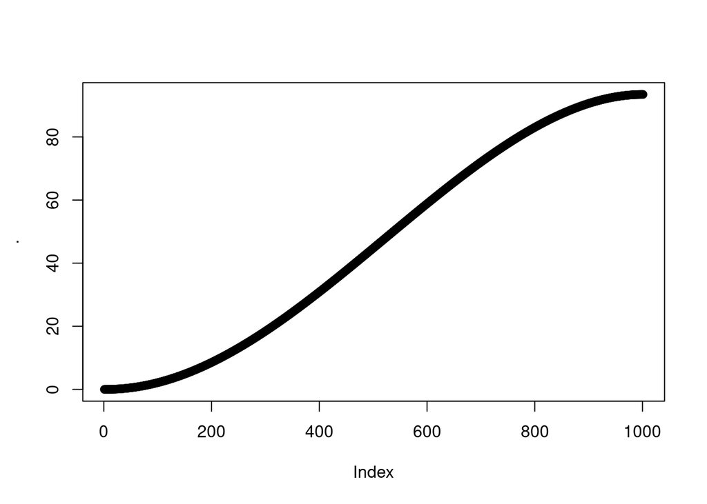

```r
seq(0,1,by=0.001) %>%
   sapply(govindarajulu_qf_s_cdf,a, sg) %>%
  plot()
```

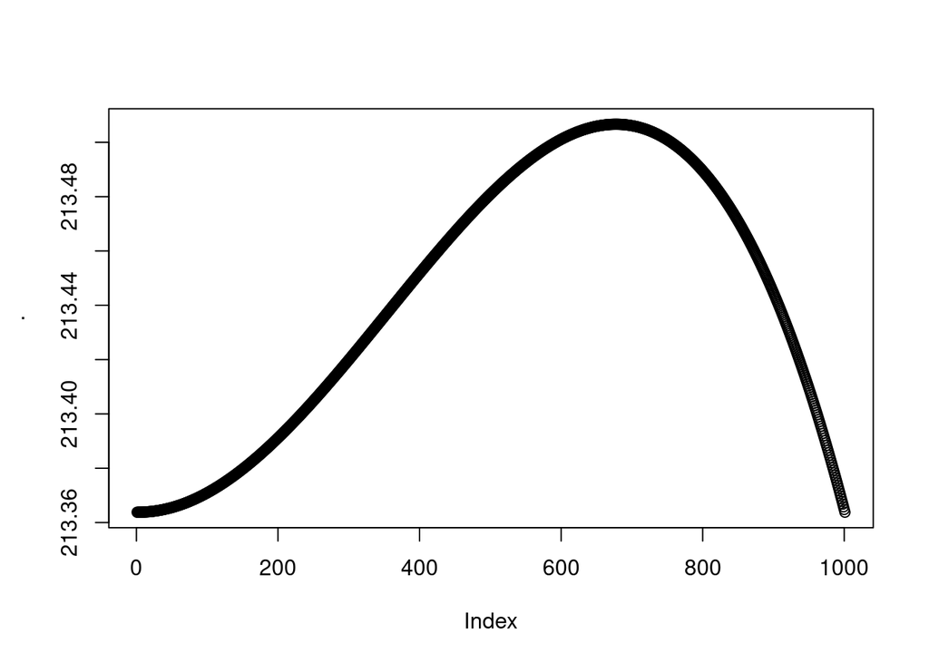

```r
 seq(0,1,by=0.001) %>%
   sapply(govindarajulu_qdf_s_pdf,a, sg) %>%
   plot()
```

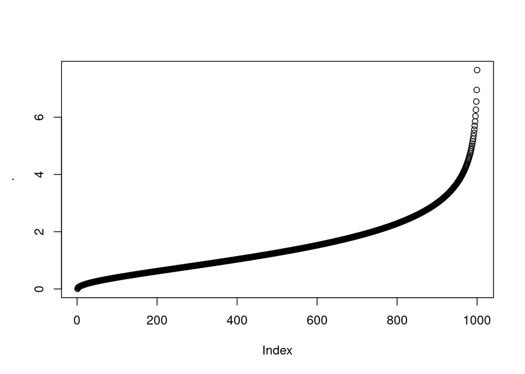

```r
lam  <- 1

 seq(0,1,by=0.001) %>%
   sapply(genexp_qf_s_cdf, a, lam) %>%
   plot()
```

```r
 genexp_qf_s_cdf(0.5, a, lam)
```

```
## [1] 1.265528
```

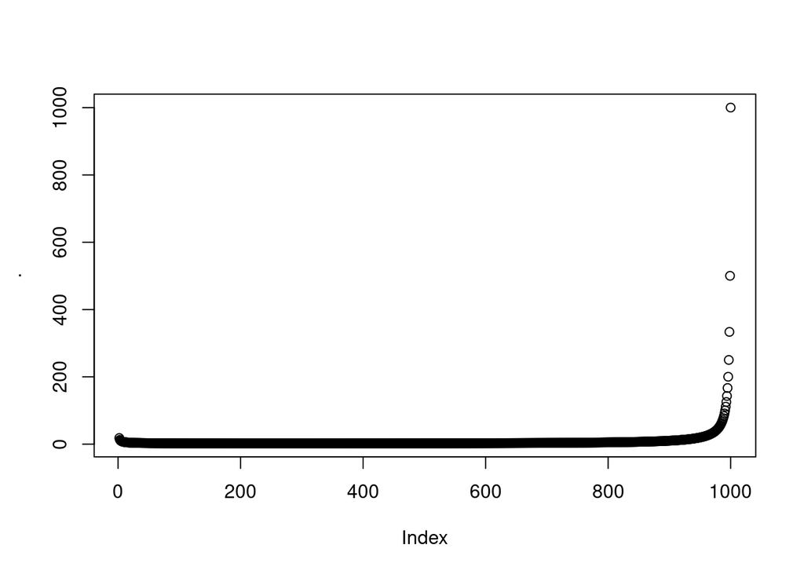

```r
 seq(0,1,by=0.001) %>%
   sapply(genexp_qdf_s_pdf, a, lam) %>%
   plot()
```

```r
govindarajulu_qf_s_cdf(0.5, a, sg)
```

```
## [1] 44.86291
```

```stan
#include govi.stan
data{
  int N;
  vector[N] u;
  real theta;
  real sigma;
}
parameters{
  real a;
}
model{
  target += genexp_qdf_s_lpdf(a | theta, 1);
  for(i in 1:N){
    target += govindarajulu_qdf_s_lpdf(u[i] | a, sigma);
  }
}
```

Prepare data and sample

```r
library(qpd)
vec_times <- c(0.1,7,36,67,84,0.2,11,40,67,84,1,12,45,67,84,1,18,46,67,85,1,18,47,72,85,1,18, 50,75,85,1,18,55,79,85,2,18,60,82,85,3,21,63,82,86,6,32,63,83,86)
vec_times_ord <- vec_times[order(vec_times)]

a=2.0915
sg=604.319/(a*(a+1))

afun <- function(u0, x_r, sg, a){
 tmp_u_r <- u0 + (x_r-qgovindarajulu(u0, sg, a))/fgovindarajulu(u0, sg, a)
 tmp_u_r[tmp_u_r<0] <- 0
 tmp_u_r[tmp_u_r>1] <- 1
 qgovindarajulu(tmp_u_r, sg, a)-x_r
}

u0s <- double(length = length(vec_times_ord))
for (r in seq_along(vec_times_ord)){
  tmp_u0 <- NULL
  tmp_u0 <- uniroot(afun, x_r=vec_times_ord[r], sg=sg, a=a, interval = c(0,1), tol = 1e-15)
  u0s[r] <- ifelse(is.null(tmp_u0), NA, tmp_u0$root)
}

dt_lst <- list(N=length(u0s), u=u0s, theta=a, sigma=1.265528)
fit <- sampling(govi_stan_model, data=dt_lst)
```

[output not shown]

```r
print(fit)
```

```
## Inference for Stan model: 502bec5f16cb03e3d8583fb6b5f80588.
## 4 chains, each with iter=2000; warmup=1000; thin=1;
## post-warmup draws per chain=1000, total post-warmup draws=4000.
##
##        mean se_mean   sd   2.5%    25%    50%    75%  97.5% n_eff Rhat
## a      2.61    0.01 0.20   2.23   2.47   2.60   2.74   3.01  1396    1
## lp__ -93.53    0.02 0.81 -95.73 -93.69 -93.23 -93.03 -92.98  1372    1
##
## Samples were drawn using NUTS(diag_e) at Fri Feb 26 11:38:58 2021.
## For each parameter, n_eff is a crude measure of effective sample size,
## and Rhat is the potential scale reduction factor on split chains (at
## convergence, Rhat=1).
```

# References

Nair, N. Unnikrishnan, P. G. Sankaran, and M. Dileepkumar. 2020. “Bayesian Inference in Quantile Functions.” *Communications in Statistics - Theory and Methods* 0 (0): 1–13. https://doi.org/ghkdr4.